# Timing Rayleigh Quotient minimization in R

This vignette is simply to record the methods and results for timing various Rayleigh Quotient minimizations with R using different functions and different ways of running the computations, in particular trying Fortran subroutines and the R byte compiler. It has been updated from a 2012 document to reflect changes in R and its packages that make it awkward to reprocess the original document on newer computers.

John C. Nash (retired professor, University of Ottawa)  
2023-9-6

## The computational task

The maximal and minimal eigensolutions of a symmetric matrix $A$ are extrema of the Rayleigh Quotient

$$R(x) = (x' A x) / (x' x)$$

We could also deal with generalized eigenproblems of the form

$$A x = e B x$$

where $B$ is symmetric and positive definite by using the Rayleigh Quotient (RQ)

$$R_g(x) = (x' A x) / (x' B x)$$

In this document, $B$ will always be an identity matrix, but some programs we test assume that it is present.

Note that the objective is scaled by the parameters, in fact by by their sum of squares. Alternatively, we may think of requiring the **normalized** eigensolution, which is given as

$$x_{normalized} = x/sqrt(x' x)$$

## Timings and speedups

In R, execution times can be measured by the function `system.time`, and in particular the third element of the object this function returns. However, various factors influence computing times in a modern computational system, so we generally want to run replications of the times. The R packages `rbenchmark` and `microbenchmark` can be used for this. I have a preference for the latter. However, to keep the time to prepare this vignette with `Sweave` or `knitR` reasonable, many of the timings will be done with only `system.time`.

There are some ways to speed up R computations.

- The code can be modified to use more efficient language structures. We show some of these below, in particular, to use vector operations.
- We can use the R byte code compiler by Luke Tierney, which has been part of the R distribution since version 2.14.
- We can use compiled code in other languages. Here we show how Fortran subroutines can be used.

## Our example matrix

We will use a matrix called the Moler matrix Nash (1979, Appendix 1). This is a positive definite symmetric matrix with one small eigenvalue. We will show a couple of examples of computing the small eigenvalue solution, but will mainly perform timings using the maximal eigenvalue solution, which we will find by minimizing the RQ of (-1) times the matrix. (The eigenvalue of this matrix is the negative of the maximal eigenvalue of the original, but the eigenvectors are equivalent to within a scaling factor for non-degenerate eigenvalues.)

Here is the code for generating the Moler matrix.

```r
molermat<-function(n){
   A<-matrix(NA, nrow=n, ncol=n)
   for (i in 1:n){
      for (j in 1:n) {
          if (i == j) A[i,i]<-i
          else A[i,j]<-min(i,j) - 2
      }
   }
   A
}
```

However, since R is more efficient with vectorized code, the following routine by Ravi Varadhan should do much better.

```r
molerfast <- function(n) {
# A fast version of `molermat'
  A <- matrix(0, nrow = n, ncol = n)
  j <- 1:n
  for (i in 1:n) {
    A[i, 1:i] <- pmin(i, 1:i) - 2
  }
  A <- A + t(A)
  diag(A) <- 1:n
  A
}
```

### Time to build the matrix

Let us see how long it takes to build the Moler matrix of different sizes. In 2012 we used the byte-code compiler, but that now seems to be active by default and NOT to give worthwhile improvements. We also include times for the `eigen()` function that computes the full set of eigensolutions very quickly.

```
     n buildi   osize eigentime bfast
1   50   3117   20216      1014  2913
2  100   3227   80216      1750   793
3  150   7476  180216      4299  1261
4  200  13669  320216      9064  1652
5  250  21728  500216     16324  2089
6  300  30808  720216     26196  2556
7  350  42327  980216     39990  3743
8  400  55014 1280216     58479  4066
9  450  69224 1620216     81164  4729
10 500  86518 2000216    108861  5224
```

```
buildi - interpreted build time
```

```
osize - matrix size in bytes; eigentime - all eigensolutions time
```

```
bfast - interpreted vectorized build time
```

```
Times converted to milliseconds
```

It does not appear that the compiler has much effect, or else it is being automatically invoked.

```
Call:
lm(formula = ti ~ n + n2)

Residuals:
   Min     1Q Median     3Q    Max
-972.2 -423.7   90.4  364.5  947.8

Coefficients:
              Estimate Std. Error t value Pr(>|t|)
(Intercept) 1974.02515  761.46575   2.592   0.0358 *
n            -14.42941    6.36040  -2.269   0.0576 .
n2             0.36680    0.01127  32.546 6.69e-09 ***
---
Signif. codes:  0 '***' 0.001 '**' 0.01 '*' 0.05 '.' 0.1 ' ' 1

Residual standard error: 647.4 on 7 degrees of freedom
Multiple R-squared:  0.9996,    Adjusted R-squared:  0.9995
F-statistic:  9162 on 2 and 7 DF,  p-value: 1.088e-12
```

```
Call:
lm(formula = tf ~ n + n2)

Residuals:
    Min      1Q  Median      3Q     Max
-943.60 -376.43   19.17  214.87  996.81

Coefficients:
              Estimate Std. Error t value Pr(>|t|)
(Intercept) 2246.86342  749.04030   3.000   0.0200 *
n             -8.10341    6.25662  -1.295   0.2363
n2             0.02996    0.01109   2.703   0.0305 *
---
Signif. codes:  0 '***' 0.001 '**' 0.01 '*' 0.05 '.' 0.1 ' ' 1

Residual standard error: 636.9 on 7 degrees of freedom
Multiple R-squared:   0.86, Adjusted R-squared:   0.82
F-statistic: 21.49 on 2 and 7 DF,  p-value: 0.001028
```

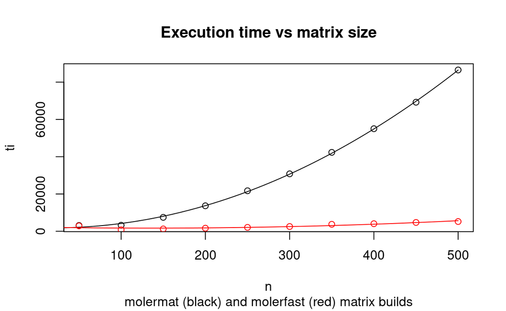

```
Call:
lm(formula = os ~ n + n2)

Residuals:
       Min         1Q     Median         3Q        Max
-7.074e-11  2.234e-12  7.557e-12  1.166e-11  3.113e-11

Coefficients:
             Estimate Std. Error   t value Pr(>|t|)
(Intercept) 2.160e+02  3.730e-11 5.791e+12   <2e-16 ***
n           0.000e+00  3.116e-13 0.000e+00        1
n2          8.000e+00  5.521e-16 1.449e+16   <2e-16 ***
---
Signif. codes:  0 '***' 0.001 '**' 0.01 '*' 0.05 '.' 0.1 ' ' 1

Residual standard error: 3.172e-11 on 7 degrees of freedom
Multiple R-squared:      1, Adjusted R-squared:      1
F-statistic: 2.09e+33 on 2 and 7 DF,  p-value: < 2.2e-16
```

[figure not shown]

## Computing the Rayleigh Quotient

The Rayleigh Quotient requires the quadratic form $x' A x$ divided by the inner product $x' x$. R lets us form this in several ways.

```r
rqdir<-function(x, AA){
  rq<-0.0
  n<-length(x) # assume x, AA conformable
  for (i in 1:n) {
     for (j in 1:n) {
        rq<-rq+x[i]*AA[[i,j]]*x[j]
     }
  }
  rq
}
```

Somewhat better (as we shall show below) is

```r
ray1<-function(x, AA){
    rq<-  t(x)%*%AA%*%x
}
```

and (believed) better still is

```r
ray2<-function(x, AA){
    rq<-  as.numeric(crossprod(x, crossprod(AA,x)))
}
```

Note that we could implicitly include the minus sign in these routines to allow for finding the maximal eigenvalue by minimizing the Rayleigh Quotient of $-A$. However, such shortcuts often rebound when the implicit negation is overlooked.

If we already have the inner product $ A x$ as vector `ax` from some other computation, then we can simply use

```r
ray3<-function(x, AA, ax=axftn){
    # ax is a function to form AA%*%x
    rq<- - as.numeric(crossprod(x, ax(x, AA)))
}
```

## Matrix-vector products

In generating the RQ, we do not actually need the matrix itself, but simply the inner product with a vector `x`, from which a second inner produce with `x` gives us the quadratic form $ x’ A x$. If `n} is the order of the problem, then for large`n`, we avoid storing and manipulating a very large matrix if we use **implicit inner product** formation. We do this with the following code. For future reference, we include the multiplication by an identity.

```r
ax<-function(x, AA){
   u<- as.numeric(AA%*%x)
}

axx<-function(x, AA){
   u<- as.numeric(crossprod(AA, x))
}
```

Note that second argument, supposedly communicating the matrix which is to be used in the matrix-vector product, is ignored in the following implicit product routine. It is present only to provide a common syntax when we wish to try different routines within other computations.

```r
aximp<-function(x, AA=1){ # implicit moler A*x
   n<-length(x)
   y<-rep(0,n)
   for (i in 1:n){
      tt<-0.
      for (j in 1:n) {
          if (i == j) tt<-tt+i*x[i]
          else tt<-tt+(min(i,j) - 2)*x[j]
      }
      y[i]<-tt
   }
   y
}
ident<-function(x, B=1) x # identity
```

However, Ravi Varadhan has suggested the following vectorized code for the implicit matrix-vector product.

```r
axmolerfast <- function(x, AA=1) {
# A fast and memory-saving version of A%*%x
# For Moler matrix. Note we need a matrix argument to match other functions
n <- length(x)
j <- 1:n
ax <- rep(0, n)
for (i in 1:n) {
term <- x * (pmin(i, j) - 2)
ax[i] <- sum(term[-i])
}
ax <- ax + j*x
ax
}
```

We can also use external language routines, for example in Fortran. However, this needs a Fortran **subroutine** which outputs the result as one of the returned components. The subroutine is in file `moler.f`.

```
      subroutine moler(n, x, ax)
      integer n, i, j
      double precision x(n), ax(n), sum
c     return ax = A * x for A = moler matrix
c     A[i,j]=min(i,j)-2 for i<>j, or i for i==j
      do 20 i=1,n
         sum=0.0
         do 10 j=1,n
            if (i.eq.j) then
               sum = sum+i*x(i)
            else
               sum = sum+(min(i,j)-2)*x(j)
            endif
 10      continue
         ax(i)=sum
 20   continue
      return
      end
```

This is then compiled in a form suitable for R use by the command (this is a command-line tool, and was run in Ubuntu Linux in a directory containing the file `moler.f` but outside this vignette):

```
R CMD SHLIB moler.f
```

This creates files `moler.o` and `moler.so`, the latter being the dynamically loadable library we need to bring into our R session.

```r
dyn.load("moler.so")
cat("Is the mat multiply loaded? ",is.loaded("moler"),"\n")
```

```
Is the mat multiply loaded?  TRUE
```

```r
axftn<-function(x, AA=1) { # ignore second argument
   n<-length(x) # could speed up by having this passed
   vout<-rep(0,n) # purely for storage
   res<-(.Fortran("moler", n=as.integer(n), x=as.double(x), vout=as.double(vout)))$vout
}
```

We can also byte compile each of the routines above

Now it is possible to time the different approaches to the matrix-vector product.

```r
dyn.load("moler.so")
cat("Is the mat multiply loaded? ",is.loaded("moler"),"\n")
```

```
Is the mat multiply loaded?  TRUE
```

```r
require(microbenchmark)
nmax<-10
ptable<-matrix(NA, nrow=nmax, ncol=6) # to hold results
# loop over sizes
for (ni in 1:nmax){
  n<-50*ni
  x<-runif(n) # generate a vector
  ptable[[ni, 1]]<-n
  AA<-molermat(n)
  tax<-system.time(oax<-replicate(100,ax(x, AA))[,1])[[1]]
  taxx<-system.time(oaxx<-replicate(100,axx(x, AA))[,1])[[1]]
  if (! identical(oax, oaxx)) stop("oaxx NOT correct")
  taxftn<-system.time(oaxftn<-replicate(100,axftn(x, AA=1))[,1])[[1]]
  if (! identical(oax, oaxftn)) stop("oaxftn NOT correct")
  taximp<-system.time(oaximp<-replicate(100,aximp(x, AA=1))[,1])[[1]]
  if (! identical(oax, oaximp)) stop("oaximp NOT correct")
  taxmfi<-system.time(oaxmfi<-replicate(100,axmolerfast(x, AA=1))[,1])[[1]]
  if (! identical(oax, oaxmfi)) stop("oaxmfi NOT correct")
  ptable[[ni, 2]]<-tax
  ptable[[ni, 3]]<-taxx
  ptable[[ni, 4]]<-taxftn
  ptable[[ni, 5]]<-taximp
  ptable[[ni, 6]]<-taxmfi
}

axtym<-data.frame(n=ptable[,1], ax=ptable[,2], axx=ptable[,3],  axftn=ptable[,4],
                  aximp=ptable[,5], axmfast=ptable[,6])
print(axtym)
```

```
     n    ax   axx axftn aximp axmfast
1   50 0.002 0.003 0.004 0.089   0.037
2  100 0.001 0.001 0.003 0.322   0.074
3  150 0.002 0.002 0.006 0.726   0.123
4  200 0.003 0.004 0.011 1.324   0.167
5  250 0.004 0.006 0.016 2.023   0.220
6  300 0.005 0.008 0.024 2.907   0.281
7  350 0.006 0.010 0.031 3.962   0.340
8  400 0.008 0.014 0.041 5.186   0.414
9  450 0.010 0.018 0.053 6.593   0.492
10 500 0.012 0.022 0.065 8.098   0.563
```

```r
adjtym<-data.frame(n=axtym$n, axx1=axtym$axx+1*bmattym$buildi,
     axxz=axtym$axx+100*bmattym$buildi,
     axftn=axtym$axftn, aximp=axtym$aximp)
print(adjtym)
```

```
     n      axx1      axxz axftn aximp
1   50  3117.350  311734.7 0.004 0.089
2  100  3226.899  322689.8 0.003 0.322
3  150  7475.563  747556.1 0.006 0.726
4  200 13669.457 1366945.3 0.011 1.324
5  250 21727.608 2172760.2 0.016 2.023
6  300 30808.367 3080835.9 0.024 2.907
7  350 42326.913 4232690.3 0.031 3.962
8  400 55014.007 5501399.3 0.041 5.186
9  450 69223.872 6922385.4 0.053 6.593
10 500 86517.897 8651787.5 0.065 8.098
```

Out of all this, we see that the Fortran implicit matrix-vector product is the overall winner at all values of `n`. Moreover, it does NOT require the creation and storage of the matrix. However, using Fortran does involve rather more work for the user, and for most applications it is likely we could live with the use of either

- the interpreted matrix-product based on `crossprod` and an actual matrix is good enough, especially if a fast matrix build is used and we have plenty of memory, or
- the interpreted or byte-code compiled implicit matrix-vector multiply `axmolerfast`.

## RQ computation times}

We have set up three versions of a Rayleigh Quotient calculation in addition to the direct form. The third form is set up to use the `axftn` routine that we have already shown is efficient. We could also use this with the implicit matrix-vector product `axmolerfast`.

It seems overkill to show the RQ computation time for all versions and matrices, so we will do the timing simply for a matrix of order 500.

```r
dyn.load("moler.so")
  n<-500
  x<-runif(n) # generate a vector
  AA<-molermat(n)
  tdi<-microbenchmark(rdi<-rqdir(x, AA))$time
  cat("Direct algorithm: ",mean(tdi)*0.001,"\n")
```

```
Direct algorithm:  17504.61
```

```r
  t1i<-microbenchmark(r1i<-ray1(x, AA))$time
  cat("ray1: mat-mult algorithm: ", mean(t1i)*0.001,"\n")
```

```
ray1: mat-mult algorithm:  257.1701
```

```r
  t2i<-microbenchmark(r2i<-ray2(x, AA))$time
  cat("ray2: crossprod algorithm: ",mean(t2i)*0.001,"\n")
```

```
ray2: crossprod algorithm:  251.6379
```

```r
  t3fi<-microbenchmark(r3i<-ray3(x, AA, ax=axftn))$time
  cat("ray3: ax Fortran + crossprod: ",mean(t3fi)*0.001,"\n")
```

```
ray3: ax Fortran + crossprod:  662.8522
```

```r
  t3ri<-microbenchmark(r3i<-ray3(x, AA, ax=axmolerfast))$time
  cat("ray3: ax fast R implicit + crossprod: ",mean(t3ri)*0.001,"\n")
```

```
ray3: ax fast R implicit + crossprod:  5552.258
```

Here we see that the use of the `crossprod` in `ray2` is very fast, and this is interpreted code. Once again, we note that all timings except those for `ray3` should have some adjustment for the building of the matrix. If storage is an issue, then `ray3`, which uses the implicit matrix-vector product in Fortran, is the approach of choice. My own preference would be to use this option if the Fortran matrix-vector product subroutine is already available for the matrix required. I would not, however, generally choose to write the Fortran subroutine for a “new” problem matrix. The fast implicit matrix-vector tool with `ray3` is also useful and quite fast if we need to minimize memory use.

## Solution by spg

To actually solve the eigensolution problem we will first use the projected gradient method `spg` from `BB`. We repeat the RQ function so that it is clear which routine we are using.

```r
rqt<-function(x, AA){
    rq<-as.numeric(crossprod(x, crossprod(AA,x)))
}
proj<-function(x) { sign(x[1])*x/sqrt(crossprod(x)) }
require(BB)
n<-100
x<-rep(1,n)
AA<-molermat(n)
evs<-eigen(AA)
tmin<-microbenchmark(amin<-spg(x, fn=rqt, project=proj, control=list(trace=FALSE), AA=AA), times=mbt)$time
#amin
tmax<-microbenchmark(amax<-spg(x, fn=rqt, project=proj, control=list(trace=FALSE), AA=-AA), times=mbt)$time
#amax
evalmax<-evs$values[1]
evecmax<-evs$vectors[,1]
evecmax<-sign(evecmax[1])*evecmax/sqrt(as.numeric(crossprod(evecmax)))
emax<-list(evalmax=evalmax, evecmax=evecmax)
# save(emax, file="temax.Rdata")
evalmin<-evs$values[n]
evecmin<-evs$vectors[,n]
evecmin<-sign(evecmin[1])*evecmin/sqrt(as.numeric(crossprod(evecmin)))
avecmax<-amax$par
avecmin<-amin$par
avecmax<-sign(avecmax[1])*avecmax/sqrt(as.numeric(crossprod(avecmax)))
avecmin<-sign(avecmin[1])*avecmin/sqrt(as.numeric(crossprod(avecmin)))
cat("minimal eigensolution: Value=",amin$value,"in time ",tmin,"\n")
```

```
minimal eigensolution: Value= 318550 in time  6034097 1348739
```

```r
cat("Eigenvalue - result from eigen=",amin$value-evalmin,"  vector max(abs(diff))=",
      max(abs(avecmin-evecmin)),"\n\n")
```

```
Eigenvalue - result from eigen= 318550   vector max(abs(diff))= 0.7660254
```

```r
#print(amin$par)
cat("maximal eigensolution: Value=",-amax$value,"in time ",tmax,"\n")
```

```
maximal eigensolution: Value= 318550 in time  1511996 1290360
```

```r
cat("Eigenvalue - result from eigen=",-amax$value-evalmax,"  vector max(abs(diff))=",
      max(abs(avecmax-evecmax)),"\n\n")
```

```
Eigenvalue - result from eigen= 314615.7   vector max(abs(diff))= 0.242489
```

```r
#print(amax$par)
```

```
     n  spgrqt tbld
1   50    4113  617
2  100   13564  818
3  150   37406 1123
4  200   83161 1667
5  250  158235 2253
6  300  269787 2625
7  350  424717 3217
8  400  626164 3604
9  450  886642 4545
10 500 1289387 5320
```

## Solution by other optimizers}

We can try other optimizers, but we must note that unlike `spg` they do not take account of the scaling. However, we can build in a transformation, since our function is always the same for all sets of parameters scaled by the square root of the parameter inner product. The function `nobj` forms the quadratic form that is the numerator of the Rayleigh Quotient using the more efficient `code{crossprod()` function

`rq<- as.numeric(crossprod(y, crossprod(AA,y)))`

but we first form

`y<-x/sqrt(as.numeric(crossprod(x)))`

to scale the parameters.

Since we are running a number of gradient-based optimizers in the wrapper `optimx::opm()`, we have reduced the matrix sizes and numbers.

```r
require(optimx)
nobj<-function(x, AA=-AA){
   y<-x/sqrt(as.numeric(crossprod(x)))
   rq<- as.numeric(crossprod(y, crossprod(AA,y)))
}

ngrobj<-function(x, AA=-AA){
   y<-x/sqrt(as.numeric(crossprod(x)))
   n<-length(x)
   dd<-sqrt(as.numeric(crossprod(x)))
   T1<-diag(rep(1,n))/dd
   T2<- x%o%x/(dd*dd*dd)
   gt<-T1-T2
   gy<- as.vector(2.*crossprod(AA,y))
   gg<-as.numeric(crossprod(gy, gt))
}
# require(optplus)
# mset<-c("L-BFGS-B", "BFGS", "CG", "spg", "ucminf", "nlm", "nlminb", "Rvmmin", "Rcgmin")
mset<-c("L-BFGS-B", "BFGS", "ncg", "spg", "ucminf", "nlm", "nlminb", "nvm")
nmax<-5
for (ni in 1:nmax){
  n<-20*ni
  x<-runif(n) # generate a vector
  AA<-molerfast(n) # make sure defined
  aall<-opm(x, fn=nobj, gr=ngrobj, method=mset, AA=-AA,
     control=list(starttests=FALSE, dowarn=FALSE))
  # optansout(aall, NULL)
  summary(aall, order=value, )
  cat("Above for n=",n," \n")
}
```

```
Above for n= 20
Above for n= 40
Above for n= 60
Above for n= 80
Above for n= 100
```

```r
ctable<-matrix(NA, nrow=10, ncol=2)
nmax<-10
for (ni in 1:nmax){
  n<-50*ni
  x<-runif(n) # generate a vector
  AA<-molerfast(n) # define matrix
  tcgu<-microbenchmark(arcgu<-optimr(x, fn=nobj, gr=ngrobj, method="ncg",
          AA=-AA), times=mbt)
  ctable[[ni,1]]<-n
  ctable[[ni,2]]<-mean(tcgu$time)*0.001
}
cgtime<-data.frame(n=ctable[,1], tcgmin=ctable[,2])
print(round(cgtime,0))
```

```
     n tcgmin
1   50    875
2  100   1347
3  150   1870
4  200   3048
5  250   4625
6  300   5892
7  350  12704
8  400  16436
9  450  16349
10 500  20424
```

## A specialized minimizer - Geradin’s method}

For comparison, let us try the Geradin routine (Appendix 1) as implemented in R by one of us (JN).

```r
cat("Test geradin with explicit matrix multiplication\n")
```

```
Test geradin with explicit matrix multiplication
```

```r
n<-10
AA<-molermat(n)
BB=diag(rep(1,n))
x<-runif(n)
tg<-microbenchmark(ag<-geradin(x, ax, bx, AA=AA, BB=BB,
   control=list(trace=FALSE)), times=mbt)
cat("Minimal eigensolution\n")
```

```
Minimal eigensolution
```

```r
print(ag)
```

```
$x
 [1] -3267519331 -1633766463  -816900263  -408487306  -204318005
 [6]  -102308689   -51453722   -26324803   -14358393    -9573058

$RQ
[1] 8.582807e-06

$ipr
[1] 43

$msg
[1] "Small gradient -- done"
```

```r
cat("Geradin time=",mean(tg$time),"\n")
```

```
Geradin time= 26942418
```

```r
tgn<-microbenchmark(agn<-geradin(x, ax, bx, AA=-AA, BB=BB,
   control=list(trace=FALSE)), times=mbt)
cat("Maximal eigensolution (negative matrix)\n")
```

```
Maximal eigensolution (negative matrix)
```

```r
print(agn)
```

```
$x
 [1]  7.416673e+11 -2.487487e+10 -7.909308e+11 -1.530738e+12
 [5] -2.219018e+12 -2.832172e+12 -3.349553e+12 -3.754090e+12
 [9] -4.032085e+12 -4.173522e+12

$RQ
[1] -31.58981

$ipr
[1] 34

$msg
[1] "Small gradient -- done"
```

```r
cat("Geradin time=",mean(tgn$time),"\n")
```

```
Geradin time= 478016.5
```

Let us time this routine with different matrix vector approaches.

```r
naximp<-function(x, A=1){ # implicit moler A*x
   n<-length(x)
   y<-rep(0,n)
   for (i in 1:n){
      tt<-0.
      for (j in 1:n) {
          if (i == j) tt<-tt+i*x[i]
          else tt<-tt+(min(i,j) - 2)*x[j]
      }
      y[i]<- -tt # include negative sign
   }
   y
}

dyn.load("moler.so")
cat("Is the mat multiply loaded? ",is.loaded("moler"),"\n")
```

```
Is the mat multiply loaded?  TRUE
```

```r
naxftn<-function(x, A) { # ignore second argument
   n<-length(x) # could speed up by having this passed
   vout<-rep(0,n) # purely for storage
   res<-(-1)*(.Fortran("moler", n=as.integer(n), x=as.double(x), vout=as.double(vout)))$vout
}


require(microbenchmark)
nmax<-10
gtable<-matrix(NA, nrow=nmax, ncol=6) # to hold results
# loop over sizes
for (ni in 1:nmax){
  n<-50*ni
  x<-runif(n) # generate a vector
  gtable[[ni, 1]]<-n
  AA<-molermat(n)
  BB<-diag(rep(1,n))
  tgax<-microbenchmark(ogax<-geradin(x, ax, bx, AA=-AA, BB=BB, control=list(trace=FALSE)), times=mbt)
  gtable[[ni, 2]]<-mean(tgax$time)
  tgaximp<-microbenchmark(ogaximp<-geradin(x, naximp, ident, AA=1, BB=1, control=list(trace=FALSE)), times=mbt)
  gtable[[ni, 3]]<-mean(tgaximp$time)
  tgaxftn<-microbenchmark(ogaxftn<-geradin(x, naxftn, ident, AA=1, BB=1, control=list(trace=FALSE)), times=mbt)
  gtable[[ni, 4]]<-mean(tgaxftn$time)
}

gtym<-data.frame(n=gtable[,1], ax=gtable[,2], aximp=gtable[,3], axftn=gtable[,4])
print(gtym)
```

```
     n       ax      aximp    axftn
1   50   932859   32987440  2396129
2  100  1141682  118373067  1670163
3  150  1607610  252936616  2745750
4  200  2275644  474660504  4370512
5  250  3159480  689657678  6343278
6  300  4207412 1075646031  9146455
7  350  5351668 1376454500 11474106
8  400  7062822 1834863458 15210628
9  450  9307312 2198459668 17962134
10 500 13527251 2792685742 22702610
```

Let us check that the solution for `n = 100` by Geradin is consistent with the answer via `eigen()`.

```r
n<-100
x<-runif(n)
# emax<-load("temax.Rdata")
evalmax<-emax$evalmax
evecmac<-emax$evecmax
ogaxftn<-geradin(x, naxftn, ident, AA=1, BB=1, control=list(trace=FALSE))
gvec<-ogaxftn$x
gval<- -ogaxftn$RQ
gvec<-sign(gvec[[1]])*gvec/sqrt(as.numeric(crossprod(gvec)))
diff<-gvec-evecmax
cat("Geradin diff eigenval from eigen result: ",gval-evalmax,"   max(abs(vector diff))=",
      max(abs(diff)), "\n")
```

```
Geradin diff eigenval from eigen result:  -8.116695e-08    max(abs(vector diff))= 9.724934e-07
```

## Perspective}

We can compare the different approaches by looking at the ratio of the best solution time for each method (compiled or interpreted, with best choice of function) to the time for the Geradin approach for the different matrix sizes. In this we will ignore the fact that some approaches do not build the matrix.

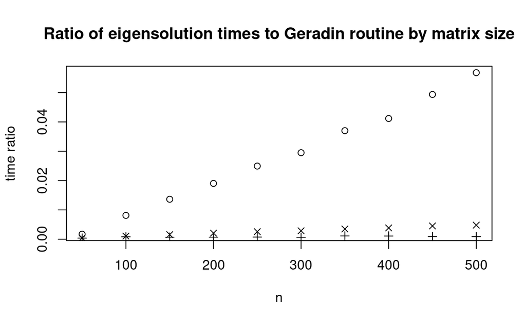

To check the value of the Geradin approach, let us use a much larger problem, with `n=2000`.

```
Times in seconds
```

```
Build = 125283137  eigen(): 7324691468   Rcgminu: 359471224  Geradin: 380829208
```

```
Ratios: build= 0.3289746 eigen= 19.23353   Rcgminu= 0.9439172
```

## Conclusions}

The Rayleigh Quotient minimization approach to eigensolutions has an intuitive appeal and seemingly offers an interesting optimization test problem, especially if we can make it computationally efficient. To improve time efficiency, we can apply the R byte code compiler, use a Fortran (or other compiled language) subroutine, and choose how we set up our objective functions and gradients. To improve memory use, we can consider using a matrix implicitly.

## Acknowledgements

This vignette originated due to a problem suggested by Gabor Grothendieck. Ravi Varadhan has provided inciteful comments and some vectorized functions which greatly altered some of the observations.

## Appendix 1: Geradin routine

```r
ax<-function(x, AA){
   u<-as.numeric(AA%*%x)
}
bx<-function(x, BB){
   v<-as.numeric(BB%*%x)
}
geradin<-function(x, ax, bx, AA, BB, control=list(trace=TRUE, maxit=1000)){
# Geradin minimize Rayleigh Quotient, Nash CMN Alg 25
# print(control)
  trace<-control$trace
  n<-length(x)
  tol<-n*n*.Machine$double.eps^2
  offset<-1e+5 # equality check offset
  if (trace) cat("geradin.R, using tol=",tol,"\n")
  ipr<-0 # counter for matrix mults
  pa<-.Machine$double.xmax
  R<-pa
  msg<-"no msg"
# step 1 -- main loop
  keepgoing<-TRUE
  while (keepgoing) {
    avec<-ax(x, AA); bvec<-bx(x, BB); ipr<-ipr+1
    xax<-as.numeric(crossprod(x, avec));
    xbx<-as.numeric(crossprod(x, bvec));
    if (xbx <= tol) {
       keepgoing<-FALSE # not really needed
       msg<-"avoid division by 0 as xbx too small"
       break
    }
    p0<-xax/xbx
    if (p0>pa) {
       keepgoing<-FALSE # not really needed
       msg<-"Rayleigh Quotient increased in step"
       break
    }
    pa<-p0
    g<-2*(avec-p0*bvec)/xbx
    gg<-as.numeric(crossprod(g)) # step 6
    if (trace) cat("Before loop: RQ=",p0," after ",ipr," products, gg=",gg,"\n")
    if (gg<tol) { # step 7
       keepgoing<-FALSE # not really needed
       msg<-"Small gradient -- done"
       break
    }
    t<- -g # step 8
    for (itn in 1:n) { # major loop step 9
       y<-ax(t, AA); z<-bx(t, BB); ipr<-ipr+1 # step 10
       tat<-as.numeric(crossprod(t, y)) # step 11
       xat<-as.numeric(crossprod(x, y))
       xbt<-as.numeric(crossprod(x, z))
       tbt<-as.numeric(crossprod(t, z))
       u<-tat*xbt-xat*tbt
       v<-tat*xbx-xax*tbt
       w<-xat*xbx-xax*xbt
       d<-v*v-4*u*w
       if (d<0) stop("Geradin: imaginary roots not possible") # step 13
       d<-sqrt(d) # step 14
       if (v>0) k<--2*w/(v+d) else k<-0.5*(d-v)/u
       xlast<-x # NOT as in CNM -- can be avoided with loop
       avec<-avec+k*y; bvec<-bvec+k*z # step 15, update
       x<-x+k*t
       xax<-xax+as.numeric(crossprod(x,avec))
       xbx<-xbx+as.numeric(crossprod(x,bvec))
       if (xbx<tol) stop("Geradin: xbx has become too small")
       chcount<-n - length(which((xlast+offset)==(x+offset)))
       if (trace) cat("Number of changed components = ",chcount,"\n")
       pn<-xax/xbx # step 17 different order
       if (chcount==0) {
         keepgoing<-FALSE # not really needed
         msg<-"Unchanged parameters -- done"
         break
       }
       if (pn >= p0) {
         if (trace) cat("RQ not reduced, restart\n")
         break # out of itn loop, not while loop (TEST!)
       }
       p0<-pn # step 19
       g<-2*(avec-pn*bvec)/xbx
       gg<-as.numeric(crossprod(g))
       if (trace) cat("Itn", itn," RQ=",p0," after ",ipr," products, gg=",gg,"\n")
       if (gg<tol){ # step 20
         if (trace) cat("Small gradient in iteration, restart\n")
         break # out of itn loop, not while loop (TEST!)
       }
       xbt<-as.numeric(crossprod(x,z)) # step 21
       w<-y-pn*z # step 22
       tabt<-as.numeric(crossprod(t,w))
       beta<-as.numeric(crossprod(g,(w-xbt*g)))
       beta<-beta/tabt # step 23
       t<-beta*t-g
    } # end loop on itn -- step 24
  } # end main loop -- step 25
  ans<-list(x=x, RQ=p0, ipr=ipr, msg=msg) # step 26
}
```

## References

J. C. Nash. *Compact numerical methods for computers: Linear algebra and function minimisation.* Bristol: Adam Hilger, 1979. Second Edition, 1990, Bristol: Institute of Physics Publications.